# Códigos - Trabalho 2 de ME904

17/11/2021

```r
# Carregando pacotes
library(tidyverse)
library(tidymodels)
library(caret)
library(corrplot)
library(ggpubr)
# pacotes para rodar os modelos de arvore com bagging e boosting do caret
library(party)
library(mboost)
library(partykit)
library(adabag)
```

```r
# tema para os graficos
tema_geral <- theme(
  legend.title = element_text(size = 8),
  legend.text = element_text(size = 8),
  legend.position = 'none',
  axis.text.x = element_text(size = 8),
  axis.line = element_line(colour = "black"),
  panel.background = element_rect(fill = "white", size = 2),
  panel.grid.major = element_line(colour = "gray",size = 0.5,
                                  linetype = "solid"))

tema_facets <- theme(
  axis.text.x = element_text(size = 8),
  axis.line = element_line(colour = "black"),
  legend.text = element_text(size = 8),
  legend.position = 'none',
  strip.background = element_rect(colour = "black", fill = "#99CCFF"),
  panel.background = element_rect(fill = "white", size = 2),
  panel.grid.major = element_line(colour = "gray",
                                  size = 0.5,
                                  linetype = "solid"),
  panel.grid.minor = element_line(colour = "gray",
                                  size = 0.5,
                                  linetype = "solid"))
```

# Análise Descritiva - Preços de seguros médicos

```r
seguro <- read_csv("insurance.csv")
```

```r
glimpse(seguro)
```

```
## Rows: 1,338
## Columns: 7
## $ age      <dbl> 19, 18, 28, 33, 32, 31, 46, 37, 37, 60, 25, 62, 23, 56, 27, 1…
## $ sex      <chr> "female", "male", "male", "male", "male", "female", "female",…
## $ bmi      <dbl> 27.900, 33.770, 33.000, 22.705, 28.880, 25.740, 33.440, 27.74…
## $ children <dbl> 0, 1, 3, 0, 0, 0, 1, 3, 2, 0, 0, 0, 0, 0, 0, 1, 1, 0, 0, 0, 0…
## $ smoker   <chr> "yes", "no", "no", "no", "no", "no", "no", "no", "no", "no", …
## $ region   <chr> "southwest", "southeast", "southeast", "northwest", "northwes…
## $ charges  <dbl> 16884.924, 1725.552, 4449.462, 21984.471, 3866.855, 3756.622,…
```

Gráficos Análise descritiva

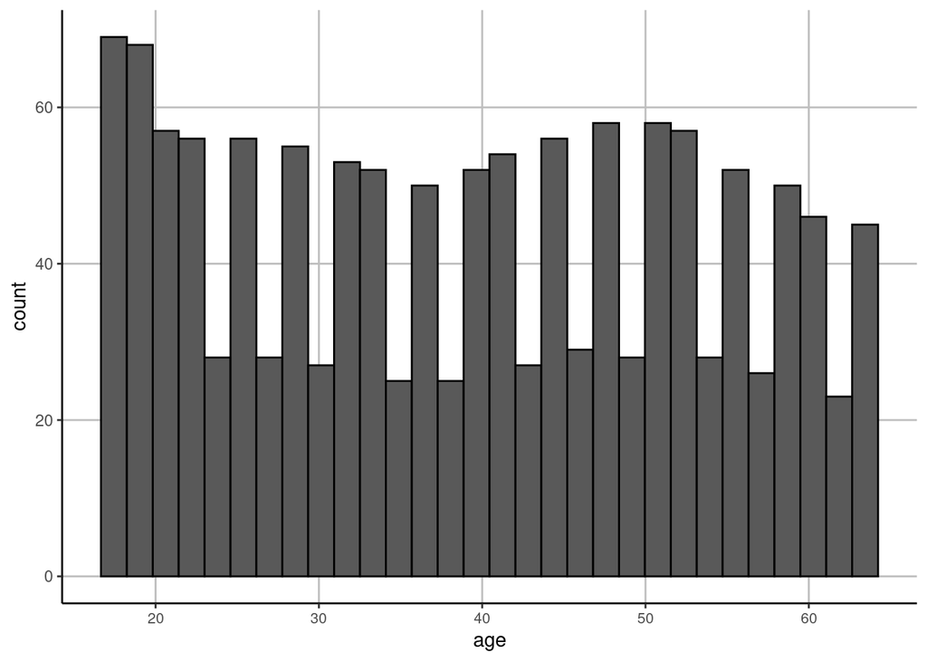

```r
(g_idade <-
  ggplot(seguro, aes(age)) +
  geom_histogram(col = 'black') +
  tema_geral)
```

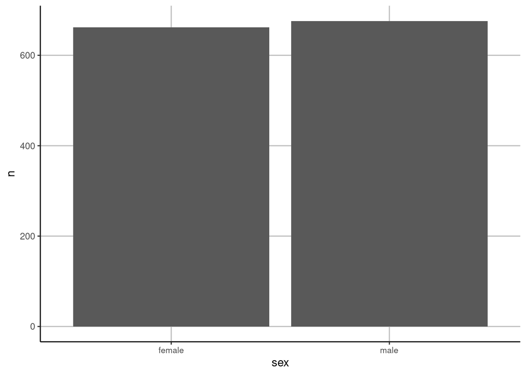

```r
(g_sex <-
    seguro %>%
    group_by(sex) %>%
    summarise(n = n()) %>%
    ggplot(aes(sex, n)) +
    geom_bar(stat = "identity") +
    tema_geral)
```

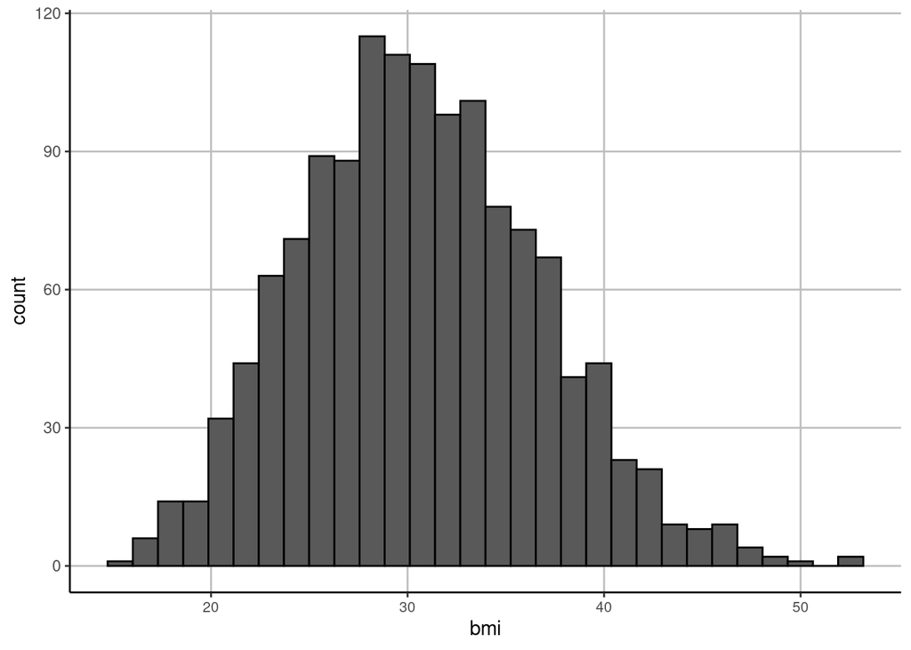

```r
(g_bmi <-
    ggplot(seguro, aes(bmi)) +
    geom_histogram(col = 'black') +
    tema_geral)
```

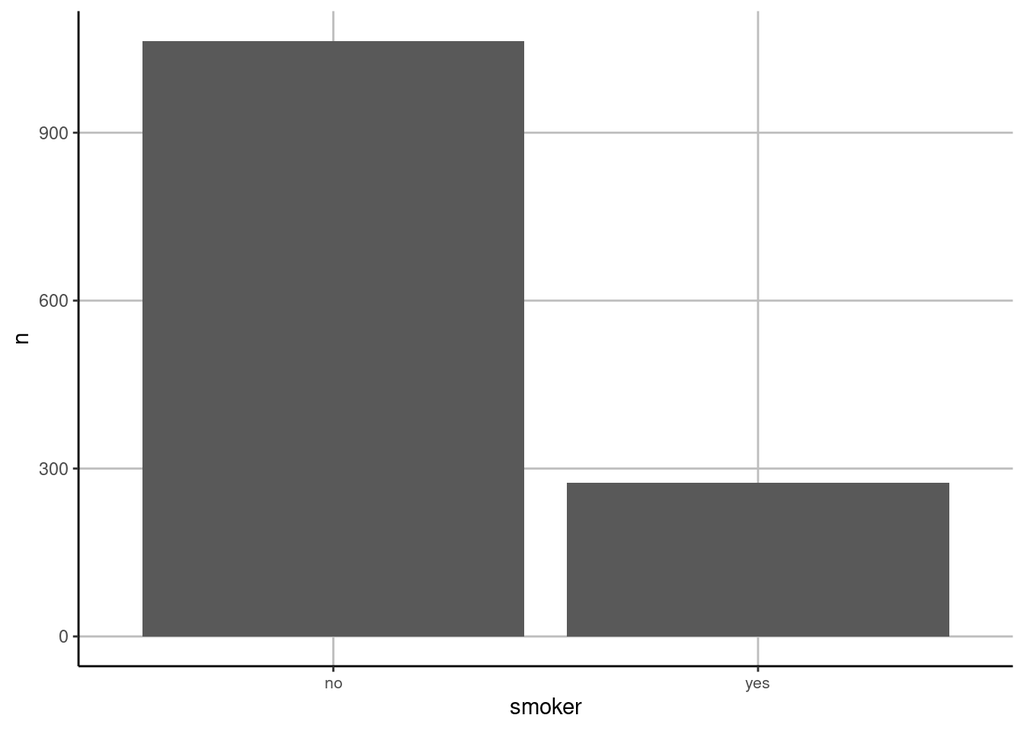

```r
(g_fumante <-
    seguro %>%
    group_by(smoker) %>%
    summarise(n = n()) %>%
    ggplot(aes(smoker, n)) +
    geom_bar(stat = "identity") +
    tema_geral)
```

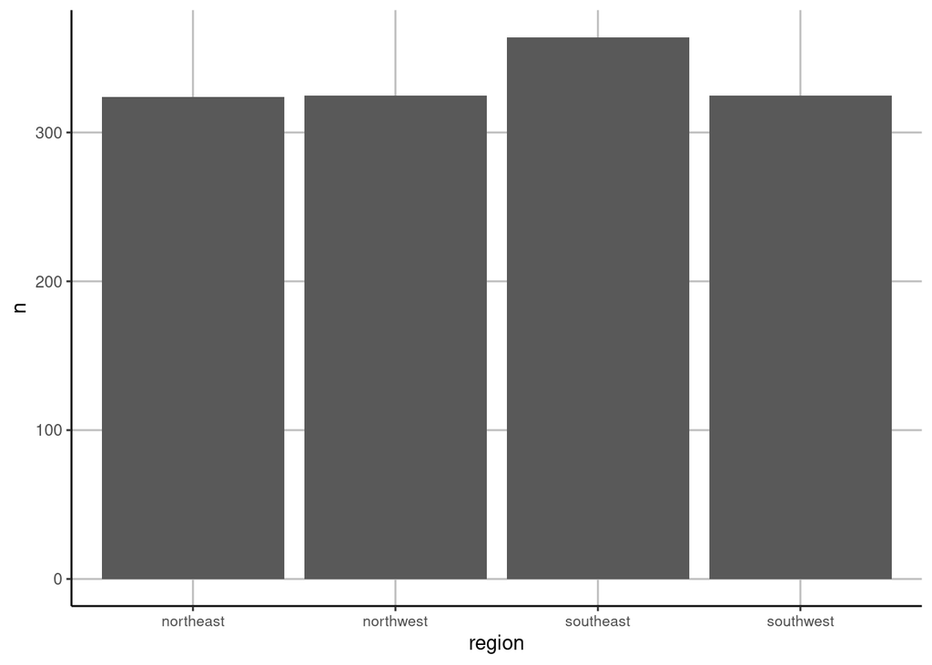

```r
(g_regiao <-
    seguro %>%
    group_by(region) %>%
    summarise(n = n()) %>%
    ggplot(aes(region, n)) +
    geom_bar(stat = "identity") +
    tema_geral)
```

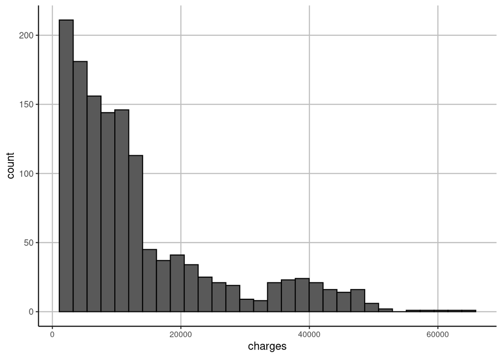

```r
(g_valor <-
    ggplot(seguro, aes(charges)) +
    geom_histogram(col = 'black') +
    tema_geral)
```

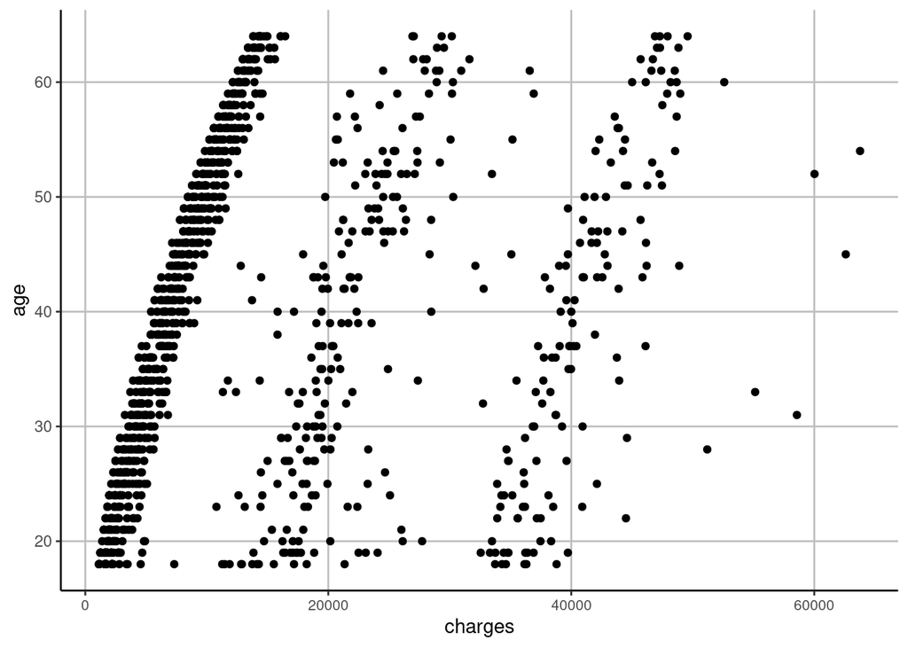

```r
(c_idade <-
    ggplot(seguro, aes(charges, age)) +
    geom_point() +
    tema_geral)
```

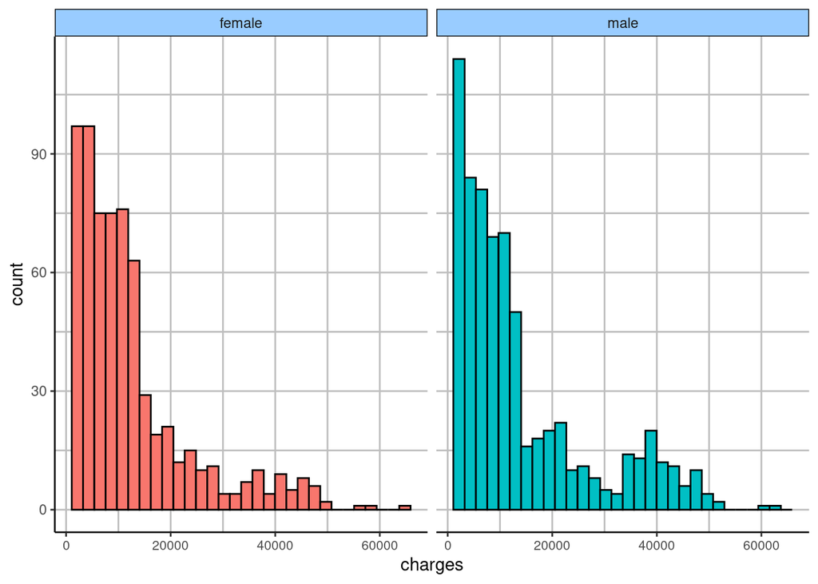

```r
(c_sex_hist <-
    seguro %>%
    ggplot(aes(charges, fill = sex)) +
    geom_histogram(col = 'black') +
    facet_wrap(. ~ sex) +
    tema_facets)
```

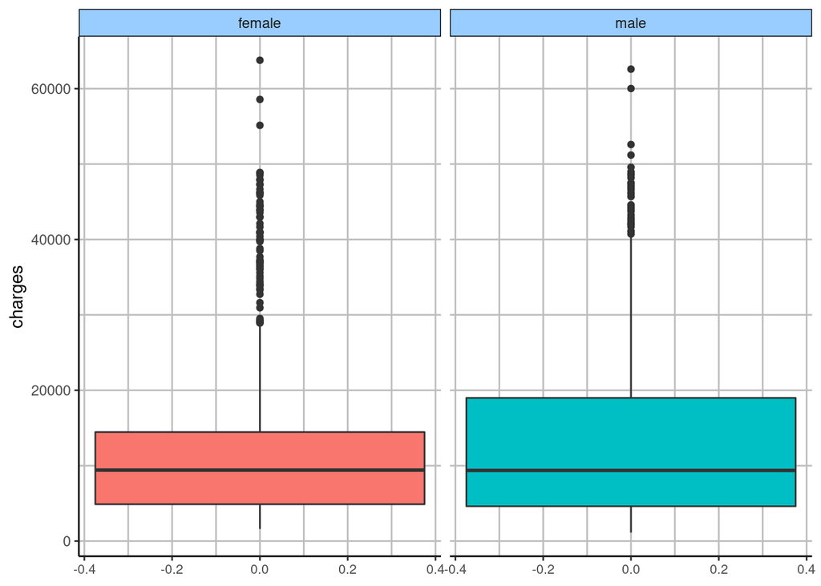

```r
(c_sex_box <-
    seguro %>%
    ggplot(aes(y = charges, fill = sex)) +
    geom_boxplot() +
    facet_wrap(. ~ sex) +
    tema_facets)
```

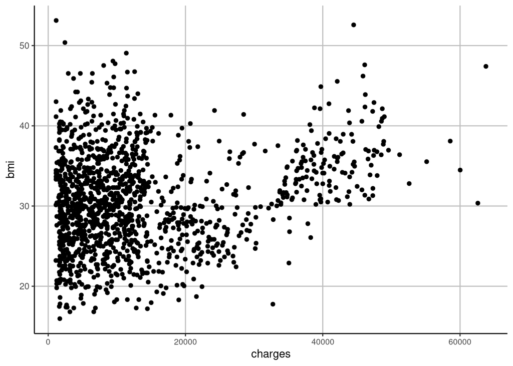

```r
(c_bmi <-
    ggplot(seguro, aes(charges, bmi)) +
    geom_point() +
    tema_geral)
```

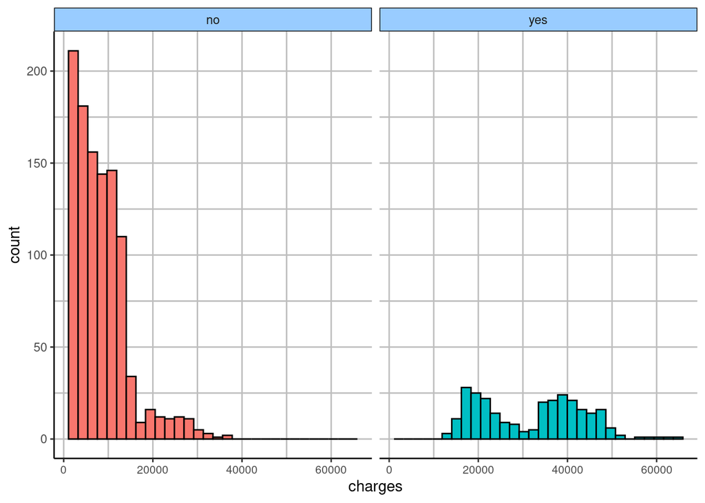

```r
(c_fumante_hist <-
    seguro %>%
    ggplot(aes(charges, fill = smoker)) +
    geom_histogram(col = 'black') +
    facet_wrap(. ~ smoker) +
    tema_facets)
```

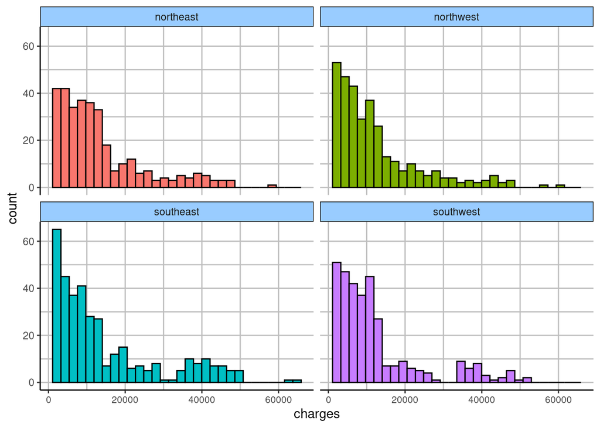

```r
(c_regiao_hist <-
    seguro %>%
    ggplot(aes(charges, fill = region)) +
    geom_histogram(col = 'black') +
    facet_wrap(. ~ region) +
    tema_facets)
```

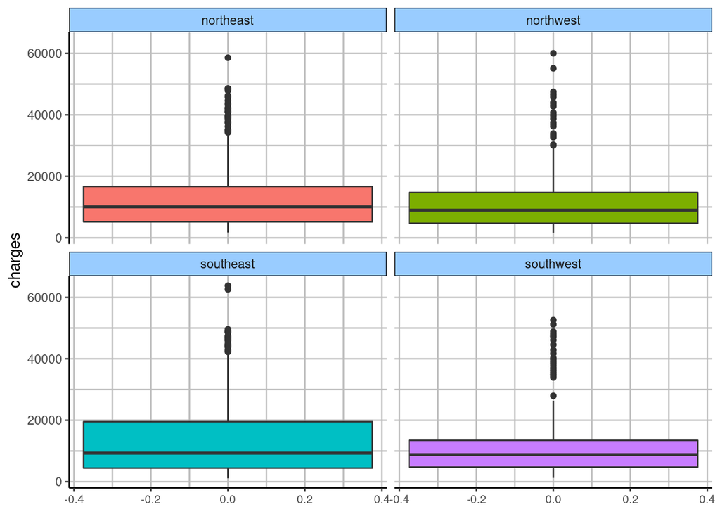

```r
(c_regiao_box <-
    seguro %>%
    ggplot(aes(y = charges, fill = region)) +
    geom_boxplot() +
    facet_wrap(. ~ region) +
    tema_facets)
```

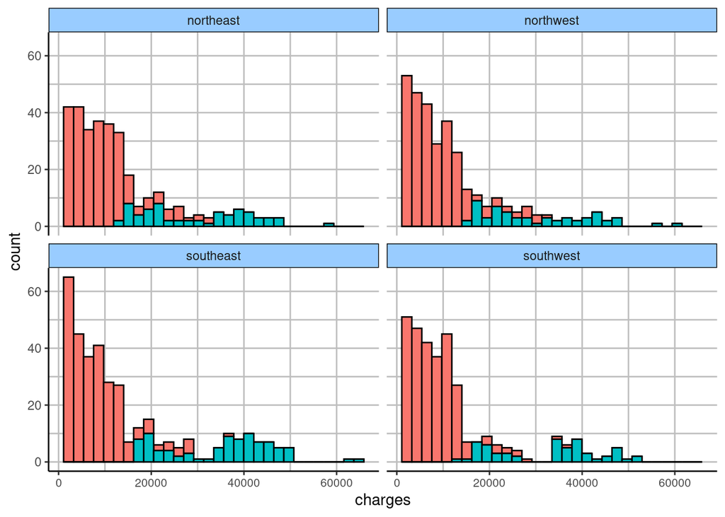

```r
(c_fumante_reg <-
    seguro %>%
    ggplot(aes(charges, fill = smoker)) +
    geom_histogram(col = 'black') +
    facet_wrap(. ~ region) +
    tema_facets)
```

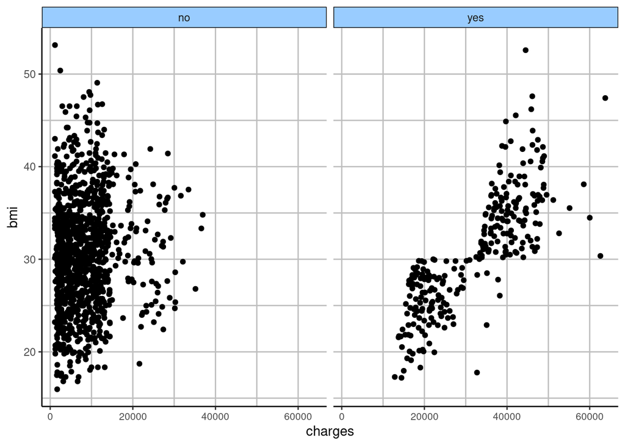

```r
(c_fumante_bmi <-
    seguro %>%
    ggplot(aes(charges, bmi)) +
    geom_point() +
    facet_wrap(. ~ smoker) +
    tema_facets)
```

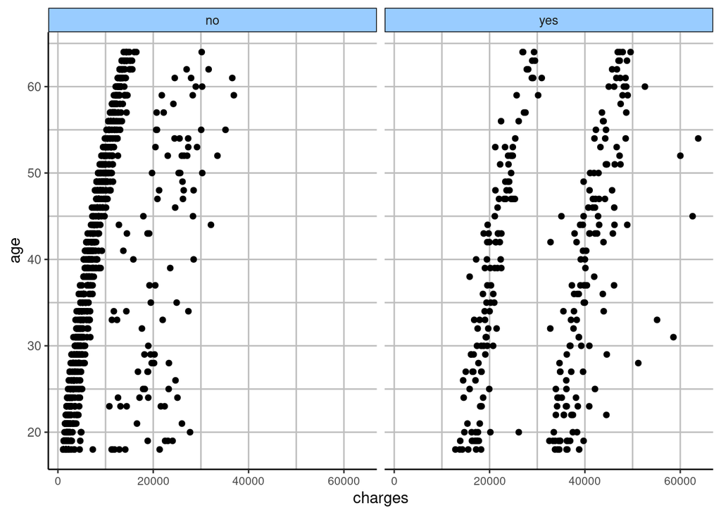

```r
(c_fumante_idade <-
    seguro %>%
    ggplot(aes(charges, age)) +
    geom_point() +
    facet_wrap(. ~ smoker) +
    tema_facets)
```

```r
# salvando graficos que vao pro relatorio
ggsave("Valor_idade.jpg", c_idade, width = 16.5, height = 8, units = "cm")
ggsave("Valor_sexo.jpg", c_sex_box, width = 16.5, height = 8, units = "cm")
ggsave("Valor_bmi.jpg", c_bmi, width = 16.5, height = 8, units = "cm")
ggsave("Valor_regiao.jpg", c_regiao_box, width = 16.5, height = 8, units = "cm")
ggsave("Valor_fumo.jpg", c_fumante_hist, width = 16.5, height = 8, units = "cm")
```

# Árvore de Regressão

Criando dados de treino e teste

```r
set.seed(123)
rnd_ind <- sample(1:nrow(seguro))
seguro_treino <- seguro[rnd_ind[1:round(nrow(seguro) * 0.8)],]
seguro_teste <- seguro[-rnd_ind[1:round(nrow(seguro) * 0.8)],]
```

## Bagging

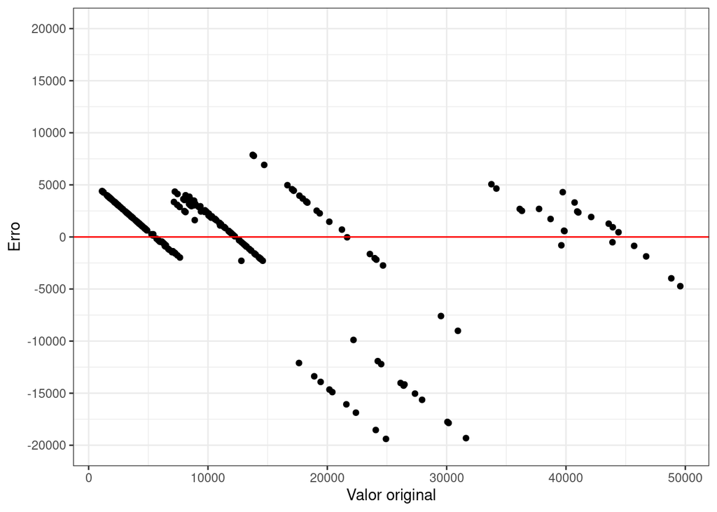

```r
mod_bag <-
  caret::train(charges ~ ., data = seguro_treino,
               method = 'treebag')

bag_teste <- predict(mod_bag, newdata = seguro_teste)

bag_teste_eqm <- mean((bag_teste - seguro_teste$charges)^2)

(g_bag_err <-
    tibble(Erro = (bag_teste - seguro_teste$charges),
           `Valor original` = seguro_teste$charges) %>%
    ggplot(aes(`Valor original`, Erro)) +
    geom_point() +
    geom_hline(yintercept = 0, colour = 'red') +
    scale_y_continuous(breaks = seq(20000, -20000, by = -5000)) +
    coord_cartesian(ylim = c(-20000, 20000)) +
    theme_bw())
```

## Boosting

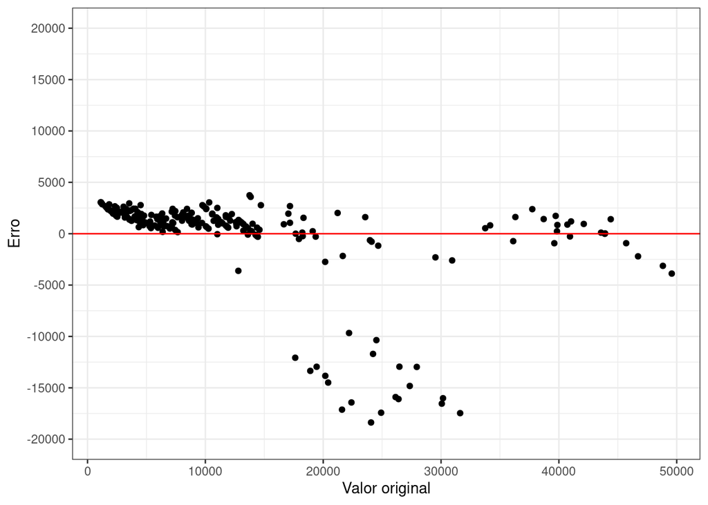

```r
mod_boost <-
  caret::train(charges ~ ., data = seguro_treino,
               method = 'blackboost',
               trControl = trainControl('cv', number = 10))

boost_teste <- predict(mod_boost, newdata = seguro_teste)

boost_teste_eqm <- mean((boost_teste - seguro_teste$charges)^2)

(g_boost_err <-
    tibble(Erro = (boost_teste - seguro_teste$charges),
           `Valor original` = seguro_teste$charges) %>%
    ggplot(aes(`Valor original`, Erro)) +
    geom_point() +
    geom_hline(yintercept = 0, colour = 'red') +
    scale_y_continuous(breaks = seq(20000, -20000, by = -5000)) +
    coord_cartesian(ylim = c(-20000, 20000)) +
    theme_bw())
```

## Erros de predicao

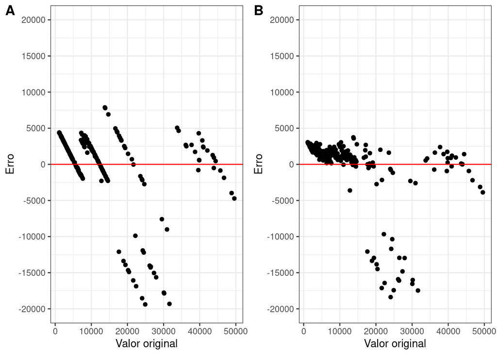

```r
(g_err <- ggarrange(g_bag_err, g_boost_err,
                    labels = c("A", "B"),
                    ncol = 2))
```

```r
ggsave("Erro_prev_regressao.jpg", g_err, width = 16.5, height = 8, units = "cm")
```

# Análise Descritiva - Tipos de estrelas

Manipulando dados

```r
dados_estrelas <- read_csv("stars.csv")

# mudando tipo/nome das variáveis
names(dados_estrelas)<-c("temperatura","luminosidade","raio","magnitude","tipo","cor","espectro")
dados_estrelas$tipo<-as.character(dados_estrelas$tipo)

# arrumando o nome das cores das estrelas
dados_estrelas[dados_estrelas$cor=="white",6]<-"White"
dados_estrelas[dados_estrelas$cor=="Blue-White",6]<-"Blue White"
dados_estrelas[dados_estrelas$cor=="Blue-white",6]<-"Blue White"
dados_estrelas[dados_estrelas$cor=="Blue white",6]<-"Blue White"
dados_estrelas[dados_estrelas$cor=="yellowish",6]<-"Yellowish"


dados_estrelas[dados_estrelas$tipo=="0" ,5]<-"Brown Dwarf"
dados_estrelas[dados_estrelas$tipo=="1" ,5]<-"Red Dwarf"
dados_estrelas[dados_estrelas$tipo=="2" ,5]<-"White Dwarf"
dados_estrelas[dados_estrelas$tipo=="3" ,5]<-"Main Sequence"
dados_estrelas[dados_estrelas$tipo=="4" ,5]<-"Supergiant"
dados_estrelas[dados_estrelas$tipo=="5" ,5]<-"Hypergiant"

dados_estrelas <- dados_estrelas %>%
  mutate(tipo = factor(tipo),
         espectro = factor(espectro),
         cor = factor(cor))
```

O banco de dados contém 240 observações e 7 variáveis:

- Temperatura Absoluta (em Kelvins)
- Cor da Estrela (white,Red,Blue,Yellow,yellow-orange etc)
- Luminosidade Relativa (L/Lo)
- Raio Relativo (R/Ro)
- Magnitude Absoluta (Mv)
- Classe Espectral (O,B,A,F,G,K,,M)
- Tipo de Estrela (anãs brancas, anãs vermelhas, gigantes vermelhas, supergigantes azuis …)

```r
glimpse(dados_estrelas)
```

```
## Rows: 240
## Columns: 7
## $ temperatura  <dbl> 3068, 3042, 2600, 2800, 1939, 2840, 2637, 2600, 2650, 270…
## $ luminosidade <dbl> 0.002400, 0.000500, 0.000300, 0.000200, 0.000138, 0.00065…
## $ raio         <dbl> 0.17000, 0.15420, 0.10200, 0.16000, 0.10300, 0.11000, 0.1…
## $ magnitude    <dbl> 16.120, 16.600, 18.700, 16.650, 20.060, 16.980, 17.220, 1…
## $ tipo         <fct> Brown Dwarf, Brown Dwarf, Brown Dwarf, Brown Dwarf, Brown…
## $ cor          <fct> Red, Red, Red, Red, Red, Red, Red, Red, Red, Red, Red, Re…
## $ espectro     <fct> M, M, M, M, M, M, M, M, M, M, M, M, M, M, M, M, M, M, M, …
```

Graficos Analise Descritiva

As estrelas são corpos celestes que são densas e emitem luz pela conversão de energia térmica em energia eletromagnética (luz). E desta forma emite luz com um certo comprimento de onda $\lambda$ que é bastante relacionado com a cor da estrela. Este comportamento pode ser ilustrado no gráfico.

A temperatura da estrela é obtida pela lei de Wienn que relaciona a temperatura com o comprimento de onda emitido pela estrela. A luminosidade de uma estrela foi obtida usando a lei de Stefan-Boltzmann.

A variável resposta do estudo é o tipo de estrela, nota-se que a luminosidade relativa é maior em estrelas gigantes. Este comportamento também é visível no gráfico abaixo no qual estrelas hipergigantes e supergigantes tem um raio maior que os outros tipos de estrelas. O raio da estrela foi estimado usando um conceito muito importante na astronomia chamado paralaxe.

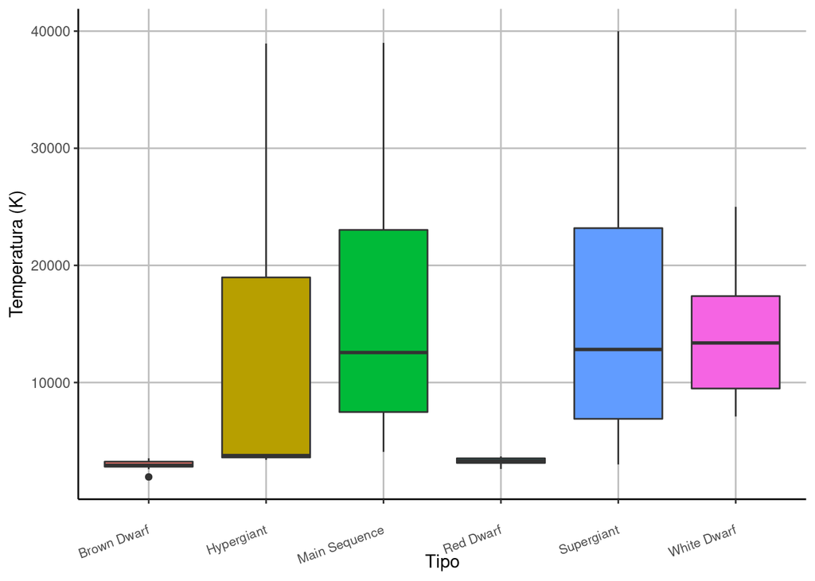

```r
(temp_stars <- ggplot(dados_estrelas) +
  geom_boxplot(aes(x = tipo, y = temperatura, fill = tipo)) +
  xlab("Tipo") + ylab("Temperatura (K)") +
  tema_geral +
  theme(axis.text.x = element_text(angle = 20, vjust = 0.5, hjust=1)))
```

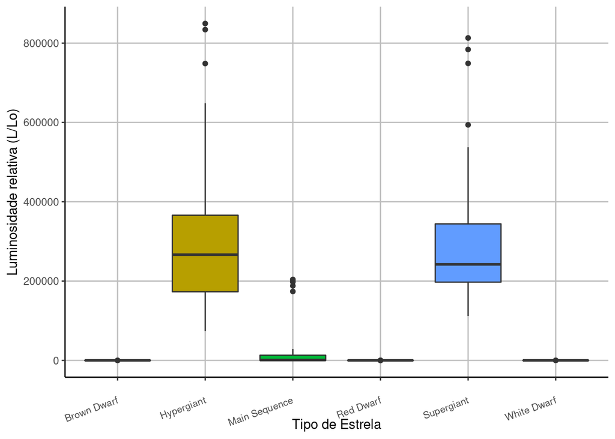

```r
(lumi_stars <- ggplot(dados_estrelas) +
  geom_boxplot(aes(x = tipo, y = luminosidade, fill = tipo)) +
  xlab("Tipo de Estrela") + ylab("Luminosidade relativa (L/Lo)") +
  scale_y_continuous(labels = function(x) format(x, scientific = F)) +
  tema_geral +
  theme(axis.text.x = element_text(angle = 20, vjust = 0.5, hjust=1)))
```

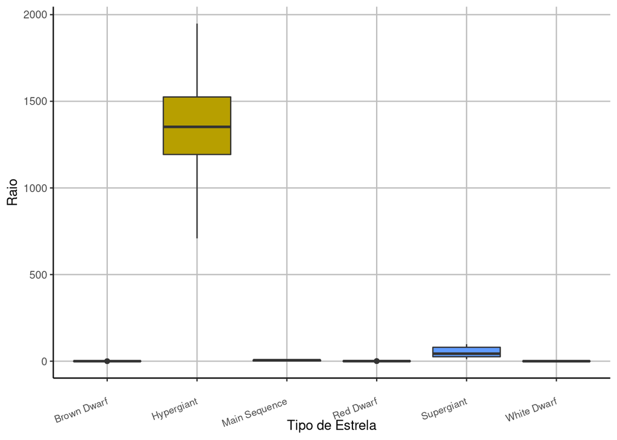

```r
temp_lumi <- ggarrange(temp_stars, lumi_stars)

(raio <- ggplot(dados_estrelas) +
  geom_boxplot(aes(x = tipo, y = raio, fill = tipo)) +
  xlab("Tipo de Estrela") + ylab("Raio") +
  tema_geral +
  theme(axis.text.x = element_text(angle = 20, vjust = 0.5, hjust=1)))
```

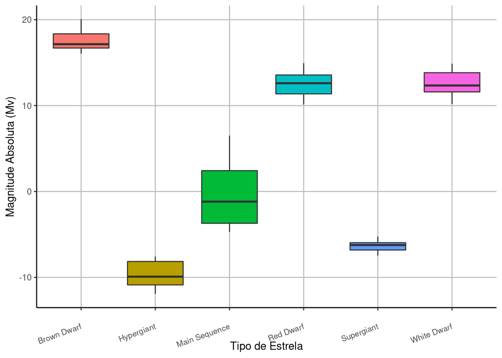

```r
(magnitude <- ggplot(dados_estrelas) +
  geom_boxplot(aes(x = tipo, y = magnitude, fill = tipo)) +
  xlab("Tipo de Estrela") + ylab("Magnitude Absoluta (Mv)") +
  # ggtitle("Luminosidade da Estrela por tipo de estrela")+
  scale_y_continuous(labels = function(x) format(x, scientific = F)) +
  tema_geral +
  theme(axis.text.x = element_text(angle = 20, vjust = 0.5, hjust=1)))
```

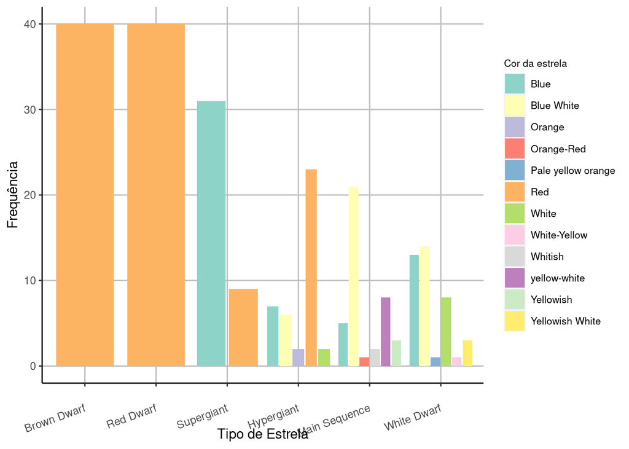

```r
raio_magnitude <- ggarrange(raio, magnitude)

ggplot(dados_estrelas %>%
         group_by(tipo,cor) %>%
         summarise(count = n()),
       aes(x = reorder(tipo,(-count)), y = count)) +
  geom_bar(aes(fill = cor), position = position_dodge2(preserve = c("total")), stat = 'identity') +
  xlab("Tipo de Estrela") + ylab("Frequência") +
  labs(fill = "Cor da estrela") +
  scale_fill_brewer(palette = "Set3") +
  theme(legend.title = element_text(size = 8),
          legend.text = element_text(size = 8),
          axis.text.x = element_text(angle = 20, vjust = 0.5, hjust=1),
          axis.line = element_line(colour = "black"),
          panel.background = element_rect(fill = "white", size = 2),
          panel.grid.major = element_line(colour = "gray",size = 0.5,
                                          linetype = "solid"))
```

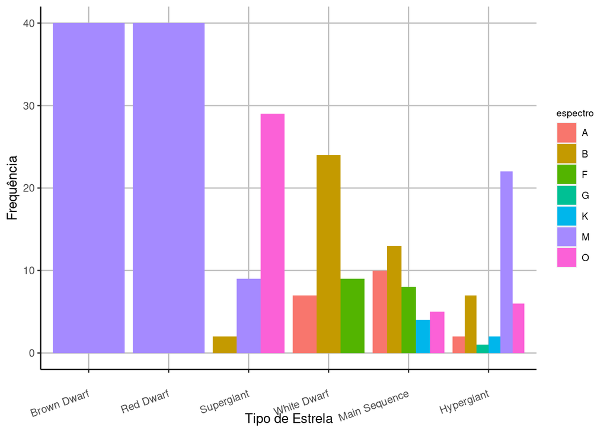

```r
ggplot(dados_estrelas %>%
         group_by(tipo,espectro) %>%
         summarise(count = n()),
       aes(x = reorder(tipo,(-count)), y = count)) +
  geom_bar(aes(fill = espectro), position = "dodge", stat = 'identity') +
  # ggtitle("Tipo da estrela em relação a cor") +
  xlab("Tipo de Estrela") + ylab("Frequência") +
  labs(color="Cor da estrela") +
  theme(legend.title = element_text(size = 8),
          legend.text = element_text(size = 8),
          axis.text.x = element_text(angle = 20, vjust = 0.5, hjust=1),
          axis.line = element_line(colour = "black"),
          panel.background = element_rect(fill = "white", size = 2),
          panel.grid.major = element_line(colour = "gray",size = 0.5,
                                          linetype = "solid"))
```

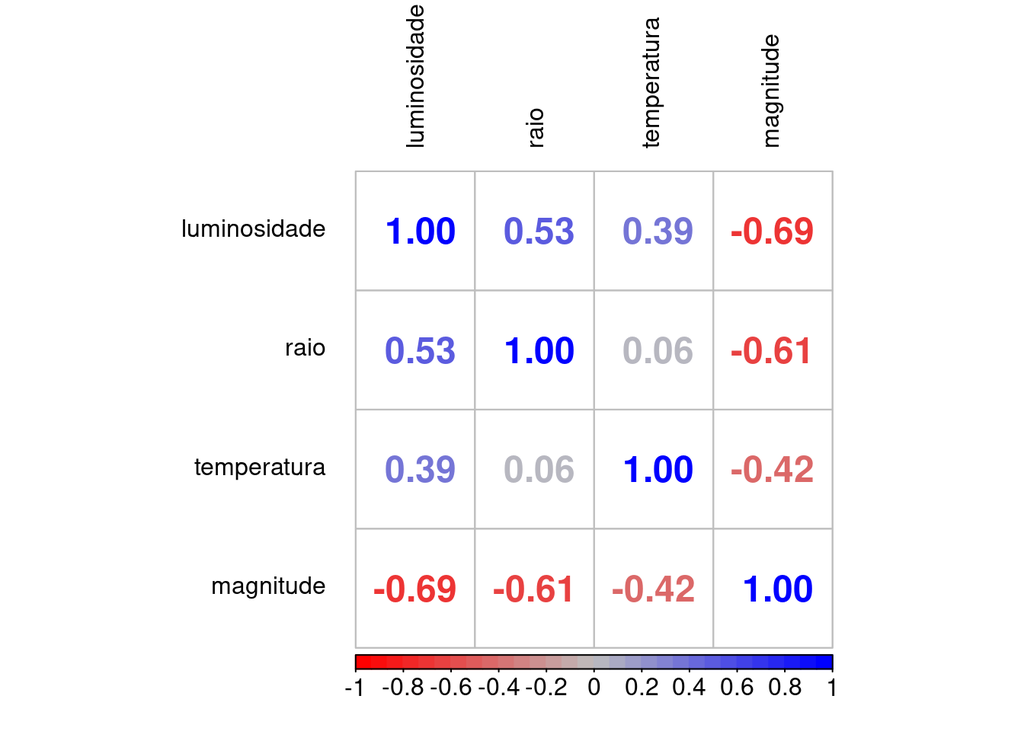

[output not shown]

```r
# grafico de correlacao
(corr_va_num_stars <- corrplot(cor(dados_estrelas[,c(1,2,3,4)]), order= c("FPC"),
                               tl.offset = 1, number.cex = 1.5, cl.pos = 'b',cl.cex = 1,
                               tl.cex = 1, method = "number", tl.col="black", addgrid.col="grey",
                               col = colorRampPalette(c("red", "gray", "blue"))(30)))
```

```r
# salvando graficos que vao pro relatorio
ggsave("temp_lumi.jpg", temp_lumi, width = 16.5, height = 8, units = "cm")
ggsave("raio_magnitude.jpg", raio_magnitude, width = 16.5, height = 8, units = "cm")
```